# Project_2_Boston_houses

## Download the data and libs

```python
!wget https://raw.githubusercontent.com/selva86/datasets/master/BostonHousing.csv
```

```
--2022-12-15 09:47:25--  https://raw.githubusercontent.com/selva86/datasets/master/BostonHousing.csv
Resolving raw.githubusercontent.com (raw.githubusercontent.com)... 185.199.108.133, 185.199.109.133, 185.199.110.133, ...
Connecting to raw.githubusercontent.com (raw.githubusercontent.com)|185.199.108.133|:443... connected.
HTTP request sent, awaiting response... 200 OK
Length: 35735 (35K) [text/plain]
Saving to: ‘BostonHousing.csv’

BostonHousing.csv   100%[===================>]  34.90K  --.-KB/s    in 0s

2022-12-15 09:47:25 (177 MB/s) - ‘BostonHousing.csv’ saved [35735/35735]
```

```python
import pandas as pd
import numpy as np
import seaborn as sns
import matplotlib.pyplot as plt
import statsmodels.api as sm
import statsmodels.formula.api as smf
from statsmodels.stats.outliers_influence import variance_inflation_factor

from scipy.stats import ttest_ind, mannwhitneyu
```

## EDA

Head of our dataset:

```python
boston = pd.read_csv('BostonHousing.csv')
boston.head(5)
```

|  | crim | zn | indus | chas | nox | rm | age | dis | rad | tax | ptratio | b | lstat | medv |
| --- | --- | --- | --- | --- | --- | --- | --- | --- | --- | --- | --- | --- | --- | --- |
| 0 | 0.00632 | 18.0 | 2.31 | 0 | 0.538 | 6.575 | 65.2 | 4.0900 | 1 | 296 | 15.3 | 396.90 | 4.98 | 24.0 |
| 1 | 0.02731 | 0.0 | 7.07 | 0 | 0.469 | 6.421 | 78.9 | 4.9671 | 2 | 242 | 17.8 | 396.90 | 9.14 | 21.6 |
| 2 | 0.02729 | 0.0 | 7.07 | 0 | 0.469 | 7.185 | 61.1 | 4.9671 | 2 | 242 | 17.8 | 392.83 | 4.03 | 34.7 |
| 3 | 0.03237 | 0.0 | 2.18 | 0 | 0.458 | 6.998 | 45.8 | 6.0622 | 3 | 222 | 18.7 | 394.63 | 2.94 | 33.4 |
| 4 | 0.06905 | 0.0 | 2.18 | 0 | 0.458 | 7.147 | 54.2 | 6.0622 | 3 | 222 | 18.7 | 396.90 | 5.33 | 36.2 |

Is there any NAs?

```python
boston.isna().sum()
```

```
crim       0
zn         0
indus      0
chas       0
nox        0
rm         0
age        0
dis        0
rad        0
tax        0
ptratio    0
b          0
lstat      0
medv       0
dtype: int64
```

How our data is stored?

```python
boston.info()
```

```
<class 'pandas.core.frame.DataFrame'>
RangeIndex: 506 entries, 0 to 505
Data columns (total 14 columns):
 #   Column   Non-Null Count  Dtype
---  ------   --------------  -----
 0   crim     506 non-null    float64
 1   zn       506 non-null    float64
 2   indus    506 non-null    float64
 3   chas     506 non-null    int64
 4   nox      506 non-null    float64
 5   rm       506 non-null    float64
 6   age      506 non-null    float64
 7   dis      506 non-null    float64
 8   rad      506 non-null    int64
 9   tax      506 non-null    int64
 10  ptratio  506 non-null    float64
 11  b        506 non-null    float64
 12  lstat    506 non-null    float64
 13  medv     506 non-null    float64
dtypes: float64(11), int64(3)
memory usage: 55.5 KB
```

**Data description**

The Boston data frame has 506 rows and 14 columns.

This data frame contains the following columns:

- **crim** per capita crime rate by town.
- **zn** proportion of residential land zoned for lots over 25,000 sq.ft.
- **indus** proportion of non-retail business acres per town.
- **chas** Charles River dummy variable (= 1 if tract bounds river; 0 otherwise).
- **nox** nitrogen oxides concentration (parts per 10 million).
- **rm** average number of rooms per dwelling.
- **age** proportion of owner-occupied units built prior to 1940.
- **dis** weighted mean of distances to five Boston employment centres.
- **rad** index of accessibility to radial highways.
- **tax** full-value property-tax rate per \$10,000.
- **ptratio** pupil-teacher ratio by town.
- **black** 1000(Bk - 0.63)^2 where Bk is the proportion of blacks by town.
- **lstat** lower status of the population (percent).
- **medv** median value of owner-occupied homes in \$1000s.

Some columns should be factors instead of numbers. Let's fix that!

```python
boston['chas'] = boston['chas'].astype('category')
boston['rad'] = boston['rad'].astype('category')
```

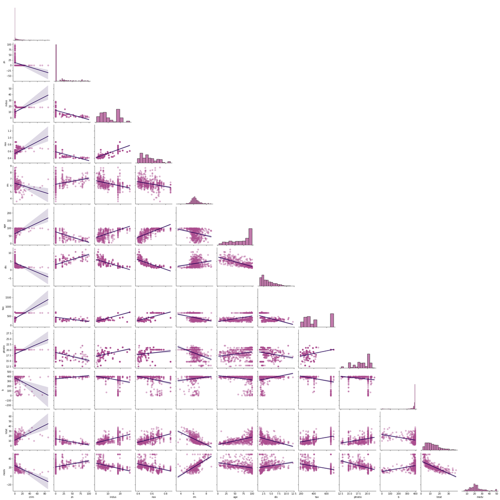

```python
sns.pairplot(boston, kind = 'reg', corner = True,
             plot_kws={'color': '#AB4D8F',
                       'line_kws':{'color':'#220055'},
                       'scatter_kws': {'alpha': 0.4,
                                       'color': '#AB4D8F'}},
             diag_kws={'color':'#AB4D8F'});
```

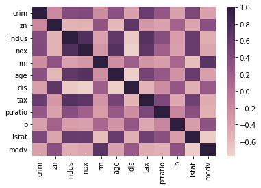

```python
sns.heatmap(boston.corr(), cmap=sns.cubehelix_palette(as_cmap=True));
```

Because out task is to understand how value of houses relates to other factors and parameters, we will took **medv** as **target**

```python
features = boston[list(boston.columns)[:-1]]
target = boston['medv']
target
features.head(3)
```

|  | crim | zn | indus | chas | nox | rm | age | dis | rad | tax | ptratio | b | lstat |
| --- | --- | --- | --- | --- | --- | --- | --- | --- | --- | --- | --- | --- | --- |
| 0 | 0.00632 | 18.0 | 2.31 | 0 | 0.538 | 6.575 | 65.2 | 4.0900 | 1 | 296 | 15.3 | 396.90 | 4.98 |
| 1 | 0.02731 | 0.0 | 7.07 | 0 | 0.469 | 6.421 | 78.9 | 4.9671 | 2 | 242 | 17.8 | 396.90 | 9.14 |
| 2 | 0.02729 | 0.0 | 7.07 | 0 | 0.469 | 7.185 | 61.1 | 4.9671 | 2 | 242 | 17.8 | 392.83 | 4.03 |

## Data standartisation

```python
numeric_features = ['crim','zn', 'indus', 'nox', 'rm', 'age',
                    'dis', 'tax', 'ptratio', 'b', 'lstat']

means = features[numeric_features].mean()
stds = features[numeric_features].std()

features_scaled = (features[numeric_features] - means) / stds
target_scaled = target
features_scaled.head(3)
```

|  | crim | zn | indus | nox | rm | age | dis | tax | ptratio | b | lstat |
| --- | --- | --- | --- | --- | --- | --- | --- | --- | --- | --- | --- |
| 0 | -0.419367 | 0.284548 | -1.286636 | -0.144075 | 0.413263 | -0.119895 | 0.140075 | -0.665949 | -1.457558 | 0.440616 | -1.074499 |
| 1 | -0.416927 | -0.487240 | -0.592794 | -0.739530 | 0.194082 | 0.366803 | 0.556609 | -0.986353 | -0.302794 | 0.440616 | -0.491953 |
| 2 | -0.416929 | -0.487240 | -0.592794 | -0.739530 | 1.281446 | -0.265549 | 0.556609 | -0.986353 | -0.302794 | 0.396035 | -1.207532 |

```python
features_scaled.describe().round(3)
```

|  | crim | zn | indus | nox | rm | age | dis | tax | ptratio | b | lstat |
| --- | --- | --- | --- | --- | --- | --- | --- | --- | --- | --- | --- |
| count | 506.000 | 506.000 | 506.000 | 506.000 | 506.000 | 506.000 | 506.000 | 506.000 | 506.000 | 506.000 | 506.000 |
| mean | -0.000 | 0.000 | 0.000 | -0.000 | -0.000 | -0.000 | -0.000 | 0.000 | -0.000 | -0.000 | -0.000 |
| std | 1.000 | 1.000 | 1.000 | 1.000 | 1.000 | 1.000 | 1.000 | 1.000 | 1.000 | 1.000 | 1.000 |
| min | -0.419 | -0.487 | -1.556 | -1.464 | -3.876 | -2.333 | -1.266 | -1.313 | -2.705 | -3.903 | -1.530 |
| 25% | -0.411 | -0.487 | -0.867 | -0.912 | -0.568 | -0.837 | -0.805 | -0.767 | -0.488 | 0.205 | -0.799 |
| 50% | -0.390 | -0.487 | -0.211 | -0.144 | -0.108 | 0.317 | -0.279 | -0.464 | 0.275 | 0.381 | -0.181 |
| 75% | 0.007 | 0.049 | 1.015 | 0.598 | 0.482 | 0.906 | 0.662 | 1.529 | 0.806 | 0.433 | 0.602 |
| max | 9.924 | 3.800 | 2.420 | 2.730 | 3.552 | 1.116 | 3.957 | 1.796 | 1.637 | 0.441 | 3.545 |

## Making full linear model

```python
X_scaled = sm.add_constant(features_scaled)
model_x = sm.OLS(target, X_scaled)
result_scaled = model_x.fit()

print(result_scaled.summary())
```

```
                            OLS Regression Results
==============================================================================
Dep. Variable:                   medv   R-squared:                       0.722
Model:                            OLS   Adj. R-squared:                  0.716
Method:                 Least Squares   F-statistic:                     116.9
Date:                Thu, 15 Dec 2022   Prob (F-statistic):          8.71e-130
Time:                        16:41:35   Log-Likelihood:                -1515.9
No. Observations:                 506   AIC:                             3056.
Df Residuals:                     494   BIC:                             3107.
Df Model:                          11
Covariance Type:            nonrobust
==============================================================================
                 coef    std err          t      P>|t|      [0.025      0.975]
------------------------------------------------------------------------------
const         22.5328      0.218    103.465      0.000      22.105      22.961
crim          -0.6030      0.281     -2.144      0.032      -1.155      -0.051
zn             0.9303      0.329      2.831      0.005       0.285       1.576
indus         -0.2880      0.417     -0.691      0.490      -1.108       0.531
nox           -1.6894      0.452     -3.740      0.000      -2.577      -0.802
rm             2.9427      0.299      9.843      0.000       2.355       3.530
age           -0.0526      0.382     -0.137      0.891      -0.804       0.699
dis           -3.1647      0.433     -7.301      0.000      -4.016      -2.313
tax            0.1405      0.402      0.349      0.727      -0.650       0.931
ptratio       -1.8918      0.286     -6.607      0.000      -2.454      -1.329
b              0.8073      0.252      3.200      0.001       0.312       1.303
lstat         -3.7614      0.373    -10.083      0.000      -4.494      -3.028
==============================================================================
Omnibus:                      204.480   Durbin-Watson:                   0.981
Prob(Omnibus):                  0.000   Jarque-Bera (JB):             1061.249
Skew:                           1.714   Prob(JB):                    3.57e-231
Kurtosis:                       9.212   Cond. No.                         5.84
==============================================================================

Notes:
[1] Standard Errors assume that the covariance matrix of the errors is correctly specified.
```

Let's try to predict taget values with our full linear model.

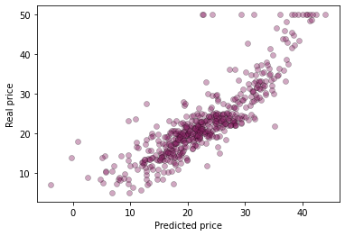

```python
prediction = result_scaled.get_prediction(X_scaled)
target_pred = prediction.predicted_mean

resid_full = target - target_pred
sns.scatterplot(x = target_pred, y = target, color = '#8B2466',
                alpha = 0.4, edgecolor = 'black');
plt.xlabel("Predicted price");
plt.ylabel("Real price");
```

Looks quite linear to me, although there are some extreme values where linearity breaks.

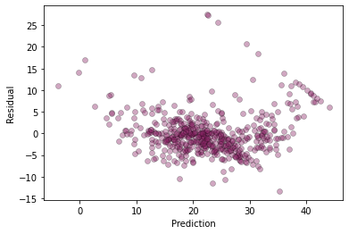

```python
resid_full = target - target_pred
sns.scatterplot(x = target_pred, y = resid_full, color = '#8B2466',
                alpha = 0.4, edgecolor = 'black')
plt.xlabel("Prediction")
plt.ylabel("Residual");
```

Looks like we have fixed maximum price.

Now, let's see if our residuals are distributed normally

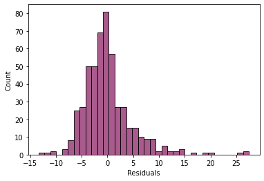

```python
sns.histplot(resid_full, color = '#8B2466', edgecolor = 'black');
plt.xlabel("Residuals")
```

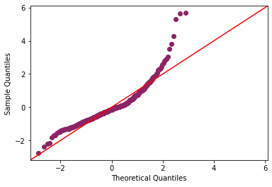

```python
sm.qqplot(resid_full, line = '45', fit = True,
          markerfacecolor = '#8B2466', markeredgecolor = '#8B2466');
```

Looks like distibution of our residuals is not normal

## Improving data

To find most significant observations that can have big influence we will calculate Cook's distances.

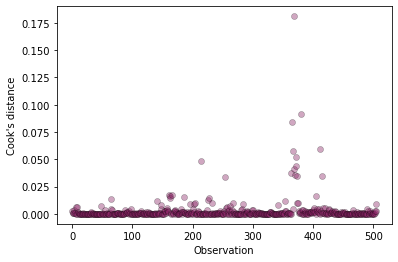

```python
influence = result_scaled.get_influence()
cooks = influence.cooks_distance

sns.scatterplot(x = features.index, y = cooks[0],
                alpha = 0.4, edgecolor = 'black',
                color = '#8B2466');

plt.xlabel("Observation");
plt.ylabel("Cook's distance");
```

```python
(cooks[0] > 0.025).sum()
```

```
14
```

```python
features_cook = features_scaled[cooks[0] <= 0.025]
target_cook = target_scaled[cooks[0] <= 0.025]
```

```python
X_cook = sm.add_constant(features_cook)
model_cook = sm.OLS(target_cook, X_cook)
result_cook = model_cook.fit()

print(result.summary())
```

[output not shown]

Our model is improved a little bit, but we can improve it more by reducing multicollinearity.

```python
vif_data = pd.DataFrame()
vif_data["feature"] = X_cook.columns
vif_data["VIF"] = [variance_inflation_factor(X_cook.values, i)
                          for i in range(len(X_cook.columns))]

vif_data.sort_values(by = 'VIF')
```

|  | feature | VIF |
| --- | --- | --- |
| 0 | const | 1.003738 |
| 10 | b | 1.367489 |
| 9 | ptratio | 1.717331 |
| 1 | crim | 1.794498 |
| 5 | rm | 2.147749 |
| 2 | zn | 2.314737 |
| 6 | age | 3.264115 |
| 8 | tax | 3.447468 |
| 11 | lstat | 3.497966 |
| 3 | indus | 3.629525 |
| 7 | dis | 3.995699 |
| 4 | nox | 4.339863 |

```python
def calculate_vif(X):
    vif_data = pd.DataFrame()
    vif_data["feature"] = X.columns
    vif_data["VIF"] = [variance_inflation_factor(X.values, i)
                            for i in range(len(X.columns))]

    return vif_data
```

```python
model_updated = sm.OLS(target_cook, X_cook.drop(columns=["nox"]))
results_updated = model_updated.fit()

print(results_updated.summary())
calculate_vif(X_cook.drop(columns=['nox'])).sort_values(by='VIF')
```

```
                            OLS Regression Results
==============================================================================
Dep. Variable:                   medv   R-squared:                       0.825
Model:                            OLS   Adj. R-squared:                  0.821
Method:                 Least Squares   F-statistic:                     226.1
Date:                Thu, 15 Dec 2022   Prob (F-statistic):          1.05e-174
Time:                        16:43:12   Log-Likelihood:                -1339.2
No. Observations:                 492   AIC:                             2700.
Df Residuals:                     481   BIC:                             2747.
Df Model:                          10
Covariance Type:            nonrobust
==============================================================================
                 coef    std err          t      P>|t|      [0.025      0.975]
------------------------------------------------------------------------------
const         22.0797      0.168    131.343      0.000      21.749      22.410
crim          -0.4081      0.258     -1.581      0.114      -0.915       0.099
zn             0.5600      0.253      2.216      0.027       0.063       1.057
indus         -0.1431      0.312     -0.459      0.647      -0.756       0.470
rm             4.6216      0.262     17.657      0.000       4.107       5.136
age           -0.9860      0.295     -3.347      0.001      -1.565      -0.407
dis           -1.9941      0.322     -6.192      0.000      -2.627      -1.361
tax           -1.1607      0.302     -3.845      0.000      -1.754      -0.568
ptratio       -1.6016      0.207     -7.738      0.000      -2.008      -1.195
b              1.1330      0.198      5.716      0.000       0.743       1.522
lstat         -2.2665      0.325     -6.965      0.000      -2.906      -1.627
==============================================================================
Omnibus:                       40.297   Durbin-Watson:                   1.130
Prob(Omnibus):                  0.000   Jarque-Bera (JB):               55.916
Skew:                           0.618   Prob(JB):                     7.21e-13
Kurtosis:                       4.095   Cond. No.                         5.44
==============================================================================

Notes:
[1] Standard Errors assume that the covariance matrix of the errors is correctly specified.
```

|  | feature | VIF |
| --- | --- | --- |
| 0 | const | 1.003642 |
| 9 | b | 1.351330 |
| 8 | ptratio | 1.536408 |
| 1 | crim | 1.793405 |
| 4 | rm | 2.118610 |
| 2 | zn | 2.312459 |
| 5 | age | 3.034115 |
| 7 | tax | 3.127993 |
| 3 | indus | 3.453068 |
| 10 | lstat | 3.490355 |
| 6 | dis | 3.618070 |

```python
model_updated = sm.OLS(target_cook, X_cook.drop(columns=['nox', 'dis']))
results_updated = model_updated.fit()

print(results_updated.summary())
calculate_vif(X_cook.drop(columns=['nox', 'dis'])).sort_values(by='VIF')
```

```
                            OLS Regression Results
==============================================================================
Dep. Variable:                   medv   R-squared:                       0.811
Model:                            OLS   Adj. R-squared:                  0.807
Method:                 Least Squares   F-statistic:                     229.2
Date:                Thu, 15 Dec 2022   Prob (F-statistic):          6.45e-168
Time:                        16:43:20   Log-Likelihood:                -1358.0
No. Observations:                 492   AIC:                             2736.
Df Residuals:                     482   BIC:                             2778.
Df Model:                           9
Covariance Type:            nonrobust
==============================================================================
                 coef    std err          t      P>|t|      [0.025      0.975]
------------------------------------------------------------------------------
const         22.0686      0.174    126.476      0.000      21.726      22.411
crim          -0.1902      0.265     -0.717      0.474      -0.712       0.331
zn            -0.1473      0.234     -0.630      0.529      -0.607       0.312
indus          0.4843      0.306      1.582      0.114      -0.117       1.086
rm             4.9037      0.268     18.329      0.000       4.378       5.429
age           -0.3276      0.285     -1.149      0.251      -0.888       0.233
tax           -1.0589      0.313     -3.384      0.001      -1.674      -0.444
ptratio       -1.8532      0.211     -8.797      0.000      -2.267      -1.439
b              1.1508      0.206      5.594      0.000       0.747       1.555
lstat         -2.2418      0.338     -6.637      0.000      -2.905      -1.578
==============================================================================
Omnibus:                       44.729   Durbin-Watson:                   1.103
Prob(Omnibus):                  0.000   Jarque-Bera (JB):               62.825
Skew:                           0.666   Prob(JB):                     2.28e-14
Kurtosis:                       4.135   Cond. No.                         5.09
==============================================================================

Notes:
[1] Standard Errors assume that the covariance matrix of the errors is correctly specified.
```

|  | feature | VIF |
| --- | --- | --- |
| 0 | const | 1.003529 |
| 8 | b | 1.351045 |
| 7 | ptratio | 1.477193 |
| 1 | crim | 1.760058 |
| 2 | zn | 1.839961 |
| 4 | rm | 2.054440 |
| 5 | age | 2.638740 |
| 3 | indus | 3.088700 |
| 6 | tax | 3.118719 |
| 9 | lstat | 3.489830 |

```python
model_updated = sm.OLS(target_cook, X_cook.drop(columns=['nox', 'dis', 'lstat']))
results_updated = model_updated.fit()

print(results_updated.summary())
calculate_vif(X_cook.drop(columns=['nox', 'dis', 'lstat'])).sort_values(by='VIF')
```

```
                            OLS Regression Results
==============================================================================
Dep. Variable:                   medv   R-squared:                       0.793
Model:                            OLS   Adj. R-squared:                  0.790
Method:                 Least Squares   F-statistic:                     231.7
Date:                Thu, 15 Dec 2022   Prob (F-statistic):          5.42e-160
Time:                        16:43:30   Log-Likelihood:                -1379.6
No. Observations:                 492   AIC:                             2777.
Df Residuals:                     483   BIC:                             2815.
Df Model:                           8
Covariance Type:            nonrobust
==============================================================================
                 coef    std err          t      P>|t|      [0.025      0.975]
------------------------------------------------------------------------------
const         22.0333      0.182    121.052      0.000      21.676      22.391
crim          -0.4151      0.275     -1.511      0.131      -0.955       0.125
zn            -0.2956      0.243     -1.216      0.224      -0.773       0.182
indus          0.3660      0.319      1.147      0.252      -0.261       0.993
rm             5.9680      0.223     26.703      0.000       5.529       6.407
age           -1.2348      0.261     -4.728      0.000      -1.748      -0.722
tax           -1.3080      0.324     -4.035      0.000      -1.945      -0.671
ptratio       -1.9103      0.220     -8.697      0.000      -2.342      -1.479
b              1.3672      0.212      6.449      0.000       0.951       1.784
==============================================================================
Omnibus:                       52.900   Durbin-Watson:                   1.051
Prob(Omnibus):                  0.000   Jarque-Bera (JB):               99.608
Skew:                           0.645   Prob(JB):                     2.35e-22
Kurtosis:                       4.787   Cond. No.                         4.39
==============================================================================

Notes:
[1] Standard Errors assume that the covariance matrix of the errors is correctly specified.
```

|  | feature | VIF |
| --- | --- | --- |
| 0 | const | 1.002598 |
| 4 | rm | 1.316371 |
| 8 | b | 1.317120 |
| 7 | ptratio | 1.474727 |
| 1 | crim | 1.731364 |
| 2 | zn | 1.823180 |
| 5 | age | 2.032289 |
| 6 | tax | 3.073850 |
| 3 | indus | 3.078235 |

```python
model_updated = sm.OLS(target_cook, X_cook.drop(columns=['nox', 'dis', 'lstat',
                                                    'indus']))
results_updated = model_updated.fit()

print(results_updated.summary())
calculate_vif(X_cook.drop(columns=['nox', 'dis',
                              'lstat', 'indus'])).sort_values(by='VIF')
```

```
                            OLS Regression Results
==============================================================================
Dep. Variable:                   medv   R-squared:                       0.793
Model:                            OLS   Adj. R-squared:                  0.790
Method:                 Least Squares   F-statistic:                     264.5
Date:                Thu, 15 Dec 2022   Prob (F-statistic):          6.18e-161
Time:                        16:43:38   Log-Likelihood:                -1380.2
No. Observations:                 492   AIC:                             2776.
Df Residuals:                     484   BIC:                             2810.
Df Model:                           7
Covariance Type:            nonrobust
==============================================================================
                 coef    std err          t      P>|t|      [0.025      0.975]
------------------------------------------------------------------------------
const         22.0338      0.182    121.016      0.000      21.676      22.392
crim          -0.4476      0.273     -1.637      0.102      -0.985       0.089
zn            -0.3662      0.235     -1.557      0.120      -0.828       0.096
rm             5.9058      0.217     27.230      0.000       5.480       6.332
age           -1.1387      0.247     -4.602      0.000      -1.625      -0.653
tax           -1.1105      0.275     -4.041      0.000      -1.651      -0.571
ptratio       -1.9285      0.219     -8.800      0.000      -2.359      -1.498
b              1.3510      0.212      6.385      0.000       0.935       1.767
==============================================================================
Omnibus:                       52.818   Durbin-Watson:                   1.049
Prob(Omnibus):                  0.000   Jarque-Bera (JB):              100.520
Skew:                           0.641   Prob(JB):                     1.49e-22
Kurtosis:                       4.806   Cond. No.                         3.18
==============================================================================

Notes:
[1] Standard Errors assume that the covariance matrix of the errors is correctly specified.
```

|  | feature | VIF |
| --- | --- | --- |
| 0 | const | 1.002593 |
| 3 | rm | 1.238785 |
| 7 | b | 1.311281 |
| 6 | ptratio | 1.467065 |
| 2 | zn | 1.706499 |
| 1 | crim | 1.712981 |
| 4 | age | 1.823210 |
| 5 | tax | 2.207966 |

```python
model_updated = sm.OLS(target_cook, X_cook.drop(columns=['nox', 'dis',
                                                    'lstat','indus',
                                                    'tax']))
results_updated = model_updated.fit()

print(results_updated.summary())
calculate_vif(X_cook.drop(columns=['nox', 'dis',
                              'lstat', 'indus',
                              'tax'])).sort_values(by='VIF')
```

```
                            OLS Regression Results
==============================================================================
Dep. Variable:                   medv   R-squared:                       0.786
Model:                            OLS   Adj. R-squared:                  0.783
Method:                 Least Squares   F-statistic:                     296.4
Date:                Thu, 15 Dec 2022   Prob (F-statistic):          1.03e-158
Time:                        16:43:45   Log-Likelihood:                -1388.4
No. Observations:                 492   AIC:                             2791.
Df Residuals:                     485   BIC:                             2820.
Df Model:                           6
Covariance Type:            nonrobust
==============================================================================
                 coef    std err          t      P>|t|      [0.025      0.975]
------------------------------------------------------------------------------
const         22.0397      0.185    119.183      0.000      21.676      22.403
crim          -0.9139      0.252     -3.631      0.000      -1.408      -0.419
zn            -0.4415      0.238     -1.854      0.064      -0.909       0.027
rm             5.9682      0.220     27.162      0.000       5.536       6.400
age           -1.4377      0.240     -5.995      0.000      -1.909      -0.966
ptratio       -2.1939      0.212    -10.331      0.000      -2.611      -1.777
b              1.5526      0.209      7.434      0.000       1.142       1.963
==============================================================================
Omnibus:                       39.902   Durbin-Watson:                   1.061
Prob(Omnibus):                  0.000   Jarque-Bera (JB):               77.269
Skew:                           0.493   Prob(JB):                     1.66e-17
Kurtosis:                       4.673   Cond. No.                         2.60
==============================================================================

Notes:
[1] Standard Errors assume that the covariance matrix of the errors is correctly specified.
```

|  | feature | VIF |
| --- | --- | --- |
| 0 | const | 1.002529 |
| 3 | rm | 1.232501 |
| 6 | b | 1.238389 |
| 5 | ptratio | 1.335237 |
| 1 | crim | 1.407633 |
| 4 | age | 1.660175 |
| 2 | zn | 1.695797 |

```python
model_updated = sm.OLS(target_cook, X_cook.drop(columns=['nox', 'dis',
                                                    'lstat','indus',
                                                    'tax', 'zn']))
results_updated = model_updated.fit()

print(results_updated.summary())
calculate_vif(X_cook.drop(columns=['nox', 'dis',
                              'lstat', 'indus',
                              'tax', 'zn'])).sort_values(by='VIF')
```

```
                            OLS Regression Results
==============================================================================
Dep. Variable:                   medv   R-squared:                       0.784
Model:                            OLS   Adj. R-squared:                  0.782
Method:                 Least Squares   F-statistic:                     353.3
Date:                Thu, 15 Dec 2022   Prob (F-statistic):          2.88e-159
Time:                        16:43:53   Log-Likelihood:                -1390.1
No. Observations:                 492   AIC:                             2792.
Df Residuals:                     486   BIC:                             2817.
Df Model:                           5
Covariance Type:            nonrobust
==============================================================================
                 coef    std err          t      P>|t|      [0.025      0.975]
------------------------------------------------------------------------------
const         22.0395      0.185    118.885      0.000      21.675      22.404
crim          -0.9582      0.251     -3.815      0.000      -1.452      -0.465
rm             5.9010      0.217     27.162      0.000       5.474       6.328
age           -1.2094      0.206     -5.863      0.000      -1.615      -0.804
ptratio       -2.0923      0.206    -10.173      0.000      -2.496      -1.688
b              1.5429      0.209      7.371      0.000       1.132       1.954
==============================================================================
Omnibus:                       38.851   Durbin-Watson:                   1.044
Prob(Omnibus):                  0.000   Jarque-Bera (JB):               74.867
Skew:                           0.482   Prob(JB):                     5.53e-17
Kurtosis:                       4.650   Cond. No.                         2.07
==============================================================================

Notes:
[1] Standard Errors assume that the covariance matrix of the errors is correctly specified.
```

|  | feature | VIF |
| --- | --- | --- |
| 0 | const | 1.002529 |
| 2 | rm | 1.198889 |
| 3 | age | 1.222305 |
| 5 | b | 1.237614 |
| 4 | ptratio | 1.246270 |
| 1 | crim | 1.394907 |

All those dropped features do not change R-squared dramatically, so this features can be exluded from further analysis

## Comparison of models

```python
preds_full = result_scaled.get_prediction(X_scaled).predicted_mean
preds_updated = results_updated.get_prediction(X_cook.drop(columns=['nox', 'dis',
                                                                    'lstat','indus',
                                                                    'tax', 'zn'])).predicted_mean
```

```python
errors_full = target_scaled - preds_full
errors_updated = target_cook - preds_updated
```

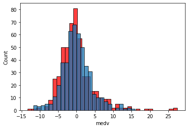

```python
sns.histplot(errors_full, color="red")
sns.histplot(errors_updated);
```

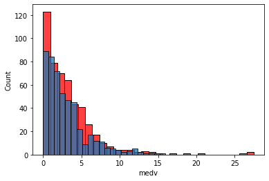

```python
sns.histplot(errors_full.abs(), color="red")
sns.histplot(errors_updated.abs());
```

```python
mannwhitneyu(errors_full.abs(), errors_updated.abs())
```

```
MannwhitneyuResult(statistic=128768.0, pvalue=0.34585027824580605)
```

```python
errors_full.abs().mean(), errors_updated.abs().mean()
```

```
(3.3357555472569773, 2.9997820867507468)
```

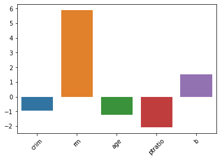

```python
sns.barplot(x = results_updated.params[1:].index, y = results_updated.params[1:])
plt.xticks(rotation=45);
```

According to our updated model, the most important features that influenced housed prices at 1990 are:

1. Average number of rooms -> larger apartments
2. Pupil-teacher ratio -> education quality
3. Race (this is an old dataset, people were more racist back then)
4. Age of the house
5. Crime rate